# Investigating HDB Resale Flat Prices across towns

```python
import pandas as pd
import matplotlib.pyplot as plt
import seaborn as sb
```

#### Verifying number of entries of population data from data.gov

```python
df = pd.read_csv('resale-flat-prices-based-on-registration-date-from-jan-2017-onwards.csv')
df.iloc[:5]
len(df)
```

```
110402
```

#### Checking for any invalid entries in each column

```python
df.isnull().sum()
```

```
month                  0
town                   0
flat_type              0
block                  0
street_name            0
storey_range           0
floor_area_sqm         0
flat_model             0
lease_commence_date    0
remaining_lease        0
resale_price           0
dtype: int64
```

### Checking the different town districts allocated by URA

```python
print(len(df['town'].unique()))
df['town'].unique()
```

```
26
```

```
array(['ANG MO KIO', 'BEDOK', 'BISHAN', 'BUKIT BATOK', 'BUKIT MERAH',
       'BUKIT PANJANG', 'BUKIT TIMAH', 'CENTRAL AREA', 'CHOA CHU KANG',
       'CLEMENTI', 'GEYLANG', 'HOUGANG', 'JURONG EAST', 'JURONG WEST',
       'KALLANG/WHAMPOA', 'MARINE PARADE', 'PASIR RIS', 'PUNGGOL',
       'QUEENSTOWN', 'SEMBAWANG', 'SENGKANG', 'SERANGOON', 'TAMPINES',
       'TOA PAYOH', 'WOODLANDS', 'YISHUN'], dtype=object)
```

#### For easier comparison of remaining lease on HDB flat, converting units of remaining lease from years to days

```python
def string_to_days(string):
    my_string = string
    if 'year' not in my_string:
        my_string = '0 years ' + my_string
    if "months" not in string:
        my_string += ' 0 months'
    tokens = my_string.split(' ')
    years = int(tokens[0])
    months = int(tokens[2])
    return years*365 + months*30
```

#### Filtering for relevant data to use as dataset (only *4-room* HDB flats & within past 2 years - for fairer comparison)

```python
df['year']= df['month'].str[:4]
df['remaining_lease_days'] = df['remaining_lease'].apply(string_to_days)
df = df.drop(columns = ['street_name','lease_commence_date','block','month'])
relevant_years = ['2020','2021']
df = df.loc[(df['flat_type']== '4 ROOM')& (df['year'].isin(relevant_years))]
df.iloc[:5]
len(df)
```

```
19332
```

#### Checking if there are significant variations in floor area across different towns that would affect comparison

[output not shown]

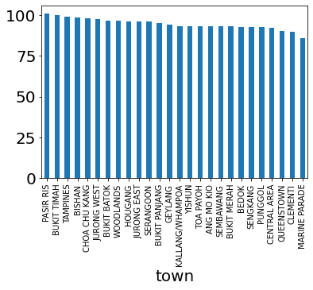

```python
df.groupby(['town'])['floor_area_sqm'].mean().sort_values(ascending = False).plot.bar()
plt.xticks(rotation = 90, size=10)
```

## Scatter plot of Resale Price against Town, with remaining lease as Z

###### Note: each point represents a *4-room* HDB flat sold in 2020-2021 from the dataset, the lighter the color the closer it is to the 100-year lease cap

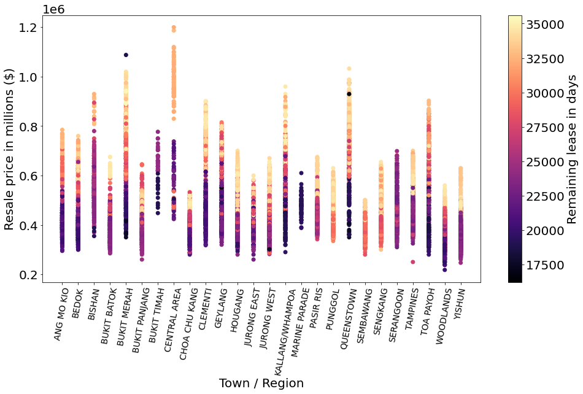

```python
plt.figure(figsize=(16, 8))
plt.xticks(rotation=80, size=14)
plt.rc('font', size = 20)
plt.scatter(df['town'], df['resale_price'], c=df['remaining_lease_days'], cmap='magma')
plt.xlabel('Town / Region')
plt.ylabel('Resale price in millions ($)')
plt.colorbar(label='Remaining lease in days')
plt.show()
```

## Let's focus on the Mean Resale Price against Town

```python
mean_resale_prices_per_town = list(df.groupby(['town'])['resale_price'].mean())
df.groupby(['town'])['resale_price'].mean()
```

```
town
ANG MO KIO         464850.338983
BEDOK              466648.411076
BISHAN             559010.711009
BUKIT BATOK        396880.238866
BUKIT MERAH        682087.601653
BUKIT PANJANG      426174.289195
BUKIT TIMAH        625277.285714
CENTRAL AREA       787678.711409
CHOA CHU KANG      412497.380531
CLEMENTI           596569.135198
GEYLANG            567638.419865
HOUGANG            434477.919807
JURONG EAST        422706.003390
JURONG WEST        403466.581197
KALLANG/WHAMPOA    583552.432401
MARINE PARADE      483610.089552
PASIR RIS          468212.411765
PUNGGOL            480064.448382
QUEENSTOWN         755314.555728
SEMBAWANG          386631.840237
SENGKANG           453309.651346
SERANGOON          468980.357542
TAMPINES           465306.508596
TOA PAYOH          580840.961009
WOODLANDS          379722.156086
YISHUN             393239.684922
Name: resale_price, dtype: float64
```

### Bar chart of Mean Resale Price against Town

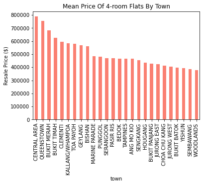

```python
df.groupby(['town'])['resale_price'].mean().sort_values(ascending = False)
plt.ylabel('Resale Price ($)')
plt.title('Mean Price Of 4-room Flats By Town')
df.groupby(['town'])['resale_price'].mean().sort_values(ascending = False).plot.bar(color = 'salmon')
```

# Geo-Spatial Visualization of the above *(population data)*

```python
#collect longtidues, latitudes, mean resale price per town
```

```python
import mplleaflet

x = list(df2['town_lon'].unique())
y = list(df2['town_lat'].unique())
z = list(pr/100 for pr in mean_resale_prices_per_town)

plt.figure(figsize= (20,10))
plt.scatter(x,y, c=z, s=z, marker='o',  alpha = 0.68, cmap = 'Oranges')
mplleaflet.display()
```

[interactive chart not shown]

### In order to experiment with and apply the Central Limit Theorem learnt during the course, a sample was drawn from each town

###### Sample e.g. Ang Mo Kio

```python
import numpy as np
def random_sample(town_data):
    chosen_idx = np.random.choice(len(town_data), replace=True, size=60)
    df_trimmed = town_data.iloc[chosen_idx]
    return df_trimmed

amk = df[df['town']=='ANG MO KIO']
sample = random_sample(amk)
sample.mean() # sample mean resale_pr != population pr
```

```
floor_area_sqm           9.215000e+01
resale_price             4.473975e+05
year                    3.367003e+237
remaining_lease_days     2.307142e+04
dtype: float64
```

## Collated Sample Data

```python
sample_std = list(int(random_sample(df[df['town']==town]).std()[1]) for town in df['town'].unique())
sample_max = list(int(random_sample(df[df['town']==town]).max()[6]) for town in df['town'].unique())
sample_min = list(int(random_sample(df[df['town']==town]).min()[6]) for town in df['town'].unique())
sample_means = list(int(random_sample(df[df['town']==town]).mean()[1]) for town in df['town'].unique())
town_samples = zip(df['town'].unique(),sample_means,sample_max,sample_min,sample_std)
samples_df=pd.DataFrame(town_samples)
samples_df.columns = ['Town','Mean Price','Max','Min','Std Dev']
samples_df
```

|  | Town | Mean Price | Max | Min | Std Dev |
| --- | --- | --- | --- | --- | --- |
| 0 | ANG MO KIO | 462611 | 770000 | 295000 | 114940 |
| 1 | BEDOK | 464733 | 710000 | 310000 | 127716 |
| 2 | BISHAN | 566783 | 858000 | 388000 | 90393 |
| 3 | BUKIT BATOK | 391661 | 615000 | 315000 | 72765 |
| 4 | BUKIT MERAH | 694357 | 1008000 | 350000 | 164235 |
| 5 | BUKIT PANJANG | 432652 | 600000 | 310000 | 63839 |
| 6 | BUKIT TIMAH | 638095 | 777000 | 470000 | 83758 |
| 7 | CENTRAL AREA | 850229 | 1200000 | 430000 | 224424 |
| 8 | CHOA CHU KANG | 416309 | 515000 | 300000 | 53496 |
| 9 | CLEMENTI | 609001 | 845000 | 338000 | 155656 |
| 10 | GEYLANG | 531079 | 815000 | 360000 | 152655 |
| 11 | HOUGANG | 433450 | 625000 | 312000 | 62132 |
| 12 | JURONG EAST | 411954 | 530000 | 300000 | 61522 |
| 13 | JURONG WEST | 408099 | 543000 | 306000 | 51665 |
| 14 | KALLANG/WHAMPOA | 592091 | 960000 | 340000 | 135063 |
| 15 | MARINE PARADE | 479168 | 565000 | 390000 | 43390 |
| 16 | PASIR RIS | 473350 | 640000 | 370000 | 69048 |
| 17 | PUNGGOL | 473984 | 573500 | 360000 | 48099 |
| 18 | QUEENSTOWN | 748391 | 938000 | 408000 | 140590 |
| 19 | SEMBAWANG | 389322 | 500000 | 308000 | 37632 |
| 20 | SENGKANG | 456405 | 625000 | 340000 | 67459 |
| 21 | SERANGOON | 471456 | 650000 | 338000 | 93255 |
| 22 | TAMPINES | 455168 | 688888 | 355000 | 47782 |
| 23 | TOA PAYOH | 598633 | 888000 | 326000 | 197836 |
| 24 | WOODLANDS | 378314 | 501000 | 238000 | 52097 |
| 25 | YISHUN | 390221 | 572000 | 280000 | 63963 |

## Geospatial representation (*Sample Data*)

```python
x = list(df2['town_lon'].unique())
y = list(df2['town_lat'].unique())
z = list(pr/100 for pr in list(int(random_sample(df[df['town']==town]).mean()[1]) for town in df['town'].unique()))

plt.figure(figsize= (20,10))
x = plt.scatter(x,y, c=z, s=z, marker='o',  alpha = 0.75, cmap = 'Blues')
mplleaflet.display()
```

[interactive chart not shown]